Innovating Higher Education

# Digital Competencies Survey

Community of Practice · University of Bern

Published

July 27, 2026

## Introduction

The **DigiComp** survey explores how members of the University of Bern experience, use and assess digital technologies in teaching, learning and research. It is part of the *Innovating Higher Education & Research for Generation Alpha* Community of Practice.

The questionnaire asked participants how often they use a range of digital tools — from generative AI and AI agents to communication platforms, cloud services and the University’s own systems — and to rate their **digital competencies** (data handling, communication, content creation, safety and problem-solving), their **AI competence** (from writing precise prompts to judging which data may be shared and weighing ethical questions), and their **learning strategies**. A closing set of items captured the perceived **effects of AI** in education — whether it de- or upskills learners and the risks it poses for cognitive and social-emotional development, trust, safety, technological dependence and educational equity — alongside a few background questions on group, age and role. The survey and the wider project are hosted on the BRIDGE network website, www.bridge-network.ch.

Responses come from two groups: **staff** (researchers, lecturers and administrative staff) and **students**. 193 were completed (**response rate 15.6%**), comprising **122 staff** and **71 students**.

The sections below summarise the main aggregate findings. Unless noted otherwise, items were rated on a five-point scale; bars show the group means with 95% confidence intervals. Staff appear in blue and students in red, and within each figure the items are ordered from the highest overall mean at the top to the lowest at the bottom.

## Use of digital tools

This section looks at how often staff and students turn to different digital systems in their everyday work and study — from communication and collaboration tools to specialised research software, AI assistants and the University’s own platforms (UniApp, ILIAS, KSL). Ratings run from 1 (never) to 5 (daily), so the figure separates the tools that have become routine, daily companions from those reached for only occasionally or for specific tasks, and shows where staff and student habits diverge.

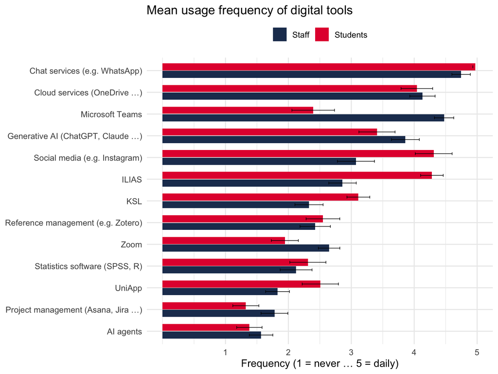

## Digital competencies (DigiComp)

Here participants rate their own confidence across five broad areas of digital competence — handling and evaluating data, communicating and collaborating, creating content, safety and security, and problem-solving. Each bar is the average of several individual items on a 1 (low) to 5 (high) scale, giving a self-assessment profile rather than a test score. The figure highlights which competence areas members feel most assured about, where confidence is comparatively lower, and how staff and students compare.

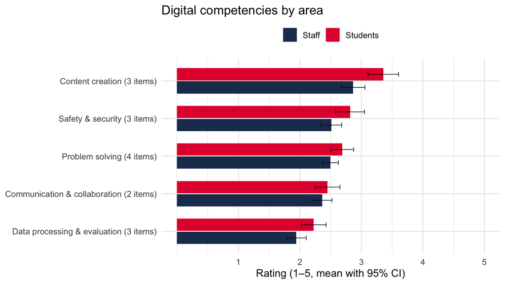

## AI competence

Beyond general digital skills, this section focuses on competencies specific to working with AI. Respondents rate how strongly they agree that they can carry out seven concrete tasks — from writing precise prompts and spotting misleading AI output to comparing tools, working iteratively, keeping their own contribution distinct, judging which data may be shared, and weighing ethical questions (1 = strongly disagree, 5 = strongly agree). A second, shorter figure adds context on how frequently AI is actually used — by respondents themselves and, as they estimate it, by their peers.

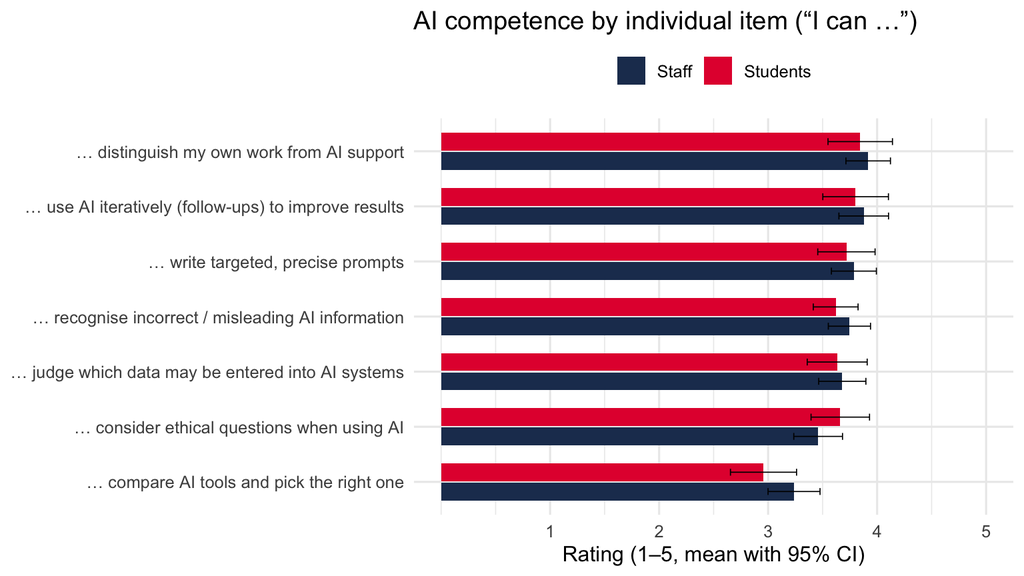

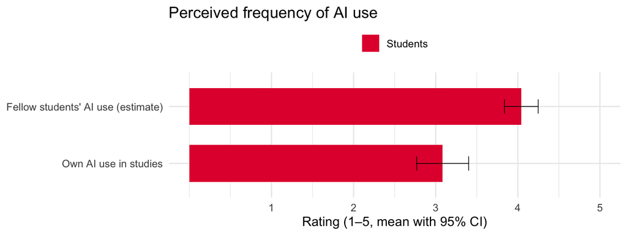

## Learning strategies

This section turns to how members organise their learning and how AI is starting to feature in it. The statements span planning and self-regulation (scheduling study time, checking one’s own understanding, adjusting when things go wrong), AI-supported study habits (using AI for follow-up questions, as a tutor, or to generate self-tests), and wishes for more support or tools (1 = does not apply, 5 = fully applies). Two items are negatively worded and marked (–) — getting distracted by digital media and struggling to structure one’s learning — so a higher bar there signals more of that difficulty rather than a good habit.

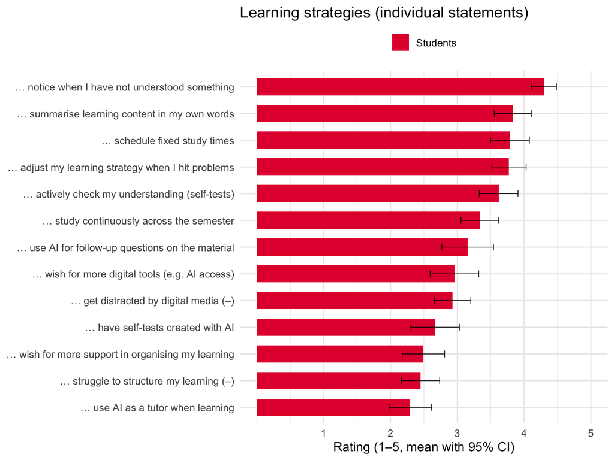

## Effects of AI

The final part of the survey shifts from skills to attitudes: how members expect AI to affect competence, and what risks they associate with its growing role in education.

### De- and upskilling

Views differ on whether leaning on AI erodes skills or builds them. These four statements capture both expectations at once — that AI reduces or increases competence — asked separately about respondents themselves and about students in general (1 = disagree, 5 = fully agree). Reading the de-skilling and up-skilling bars side by side shows how optimistic or cautious each group is, and whether people judge the effect differently for students than for themselves.

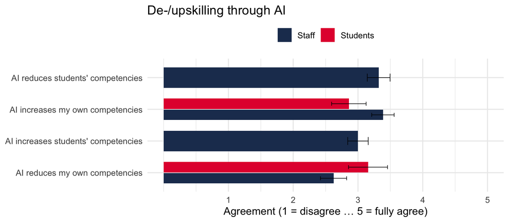

### Perceived risks

Finally, respondents weigh how much of a risk AI in education poses across six areas — cognitive and social-emotional development, trust in education, safety, dependence on technology, and educational equity (1 = very low, 5 = very high). The figure shows which concerns weigh most heavily and where staff and students see the picture differently.

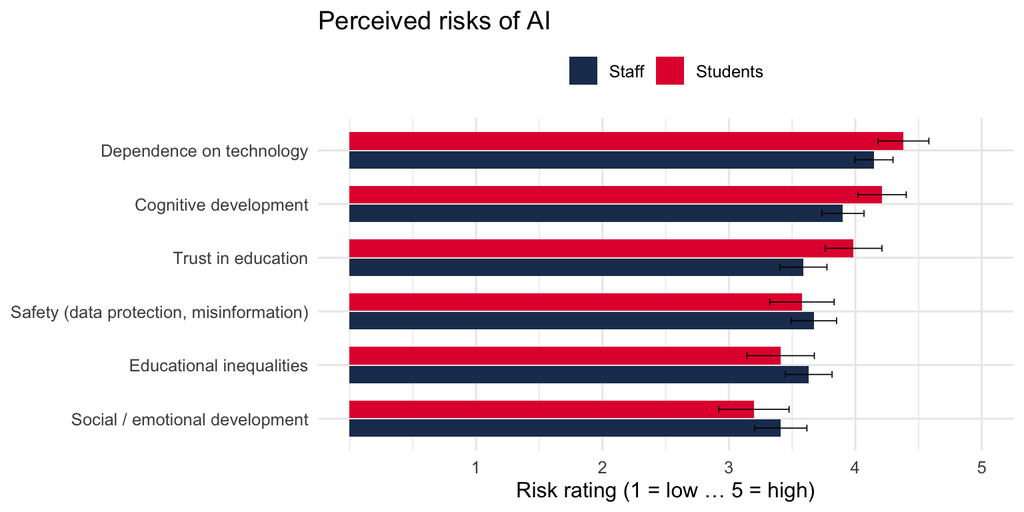

Respondents were also asked to name the single area they consider the greatest risk. The chart below breaks those choices down within each group, showing where staff and students concentrate their strongest concern.

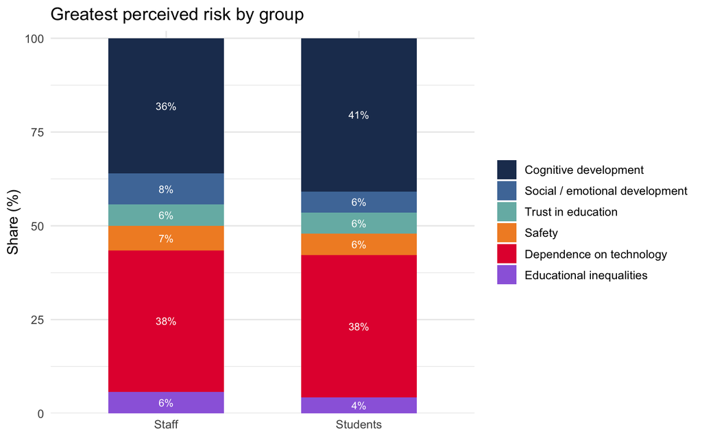